# R Notebook

This is the mark-up file for the Datenanalyse 2 homework assignment.

```r
library("rio")
x <- import("https://docs.google.com/spreadsheets/d/1SWEakSjZUvvV3w8peOf5FHrGI9NTEDls3c9zETVZ5kQ/export?format=csv&gid=447556196")
str(x)
```

```
'data.frame':   720 obs. of  31 variables:
 $ Artist_Albums_Number             : int  0 0 1 1 1 1 1 1 1 1 ...
 $ Artist_Albums_Tracks_Number      : int  0 0 8 8 8 8 8 8 8 8 ...
 $ Artist_Appearances_Number        : int  9 9 2 2 2 2 2 2 2 2 ...
 $ Artist_Appearances_Tracks_Number : int  502 502 30 30 30 30 30 30 30 30 ...
 $ Artist_Compilations_Number       : int  0 0 0 0 0 0 0 0 0 0 ...
 $ Artist_Compilations_Tracks_Number: int  0 0 0 0 0 0 0 0 0 0 ...
 $ Artist_Follower                  : int  713401 713401 601346 601346 601346 601346 601346 601346 601346 601346 ...
 $ Artist_ID                        : chr  "2NjfBq1NflQcKSeiDooVjY" "2NjfBq1NflQcKSeiDooVjY" "1qQLhymHXFPtP5U8KNKsm6" "1qQLhymHXFPtP5U8KNKsm6" ...
 $ Artist_Popularity                : int  91 91 83 83 83 83 83 83 83 83 ...
 $ Artist_Singles_Number            : int  3 3 15 15 15 15 15 15 15 15 ...
 $ Artist_Singles_Tracks_Number     : int  10 10 15 15 15 15 15 15 15 15 ...
 $ Genre                            : chr  "pop" "pop" "Hip Hop" "Hip Hop" ...
 $ Release_Date                     : chr  "2019-05-10" "2019-07-15" "2019-10-25" "2019-08-23" ...
 $ Streams                          : int  106824437 2327995 79193552 54619683 48552840 46784729 43436284 35294439 30904982 28153458 ...
```

[output cut: 17 more lines]

```r
x$commentCount <- as.integer(x$commentCount)
x$viewsCount <- as.numeric(x$viewsCount)
```

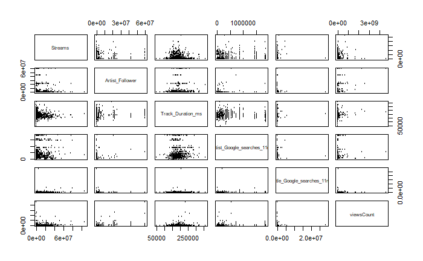

```r
library("dplyr")
drop.cols <- c('Artist_ID', 'Genre', 'Release_Date', 'Track_Artist', 'Track_ID', 'Track_Title', 'video_ID')
numeric_x <- select(x, -one_of(drop.cols))
keep.cols <- c('Streams', 'Artist_Follower', 'Track_Duration_ms', 'Artist_Google_searches_11m', 'Title_Google_searches_11m',
               'viewsCount')
# keep.cols <- c('Streams', 'viewsCount', 'Title_Youtube_searches_11m')
selected_pairs <- select(x, keep.cols)
pairs(selected_pairs, cex=0.5)
```

Descriptive statistics

```r
summary(numeric_x)
```

```
 Artist_Albums_Number Artist_Albums_Tracks_Number Artist_Appearances_Number Artist_Appearances_Tracks_Number
 Min.   : 0.000       Min.   :  0.0               Min.   :  0.00            Min.   :   0.0
 1st Qu.: 2.000       1st Qu.: 26.0               1st Qu.: 12.00            1st Qu.: 140.0
 Median : 5.000       Median : 86.0               Median : 28.00            Median : 479.0
 Mean   : 5.508       Mean   :103.2               Mean   : 48.43            Mean   : 526.9
 3rd Qu.: 8.000       3rd Qu.:159.0               3rd Qu.: 59.00            3rd Qu.: 786.0
 Max.   :20.000       Max.   :299.0               Max.   :375.00            Max.   :2583.0

 Artist_Compilations_Number Artist_Compilations_Tracks_Number Artist_Follower    Artist_Popularity
 Min.   :0.0000             Min.   : 0.000                    Min.   :    9449   Min.   :60.00
 1st Qu.:0.0000             1st Qu.: 0.000                    1st Qu.:  575873   1st Qu.:74.00
 Median :0.0000             Median : 0.000                    Median :  889326   Median :80.00
 Mean   :0.1056             Mean   : 2.579                    Mean   : 5710132   Mean   :81.22
 3rd Qu.:0.0000             3rd Qu.: 0.000                    3rd Qu.: 3129993   3rd Qu.:84.25
 Max.   :2.0000             Max.   :57.000                    Max.   :59828212   Max.   :99.00

 Artist_Singles_Number Artist_Singles_Tracks_Number    Streams          Track_Duration_ms Track_Popularity
 Min.   :  3.00        Min.   :  4.00               Min.   :    43688   Min.   : 51104    Min.   : 0.00
 1st Qu.: 11.00        1st Qu.: 12.00               1st Qu.:   799953   1st Qu.:162634    1st Qu.:50.00
 Median : 19.00        Median : 26.00               Median :  3033628   Median :182656    Median :58.00
 Mean   : 23.18        Mean   : 29.01               Mean   :  8595051   Mean   :187680    Mean   :58.65
 3rd Qu.: 29.00        3rd Qu.: 35.00               3rd Qu.: 11802780   3rd Qu.:204396    3rd Qu.:69.00
 Max.   :213.00        Max.   :128.00               Max.   :106824437   Max.   :361946    Max.   :99.00

 Title_Artist_Google_searches_11m Title_Artist_Youtube_searches_11m Title_Google_searches_11m
 Min.   :     0                   Min.   :      0                   Min.   :       0
 1st Qu.:     1                   1st Qu.:     10                   1st Qu.:       0
 Median :  1215                   Median :   1292                   Median :    4666
 Mean   : 10283                   Mean   :  58811                   Mean   :  106718
 3rd Qu.:  7100                   3rd Qu.:   9904                   3rd Qu.:   32263
 Max.   :398000                   Max.   :6870200                   Max.   :28689090

 Title_Youtube_searches_11m  Total_tracks    Artist_Google_searches_11m Artist_Youtube_searches_11m
 Min.   :        0          Min.   :   5.0   Min.   :      1            Min.   :      10
 1st Qu.:        0          1st Qu.: 239.0   1st Qu.: 183522            1st Qu.:  270454
 Median :     6488          Median : 678.0   Median : 336545            Median :  504090
 Mean   :   662186          Mean   : 661.6   Mean   : 513368            Mean   : 2179428
 3rd Qu.:   179120          3rd Qu.: 955.8   3rd Qu.: 608772            3rd Qu.: 1705727
 Max.   :134580909          Max.   :2699.0   Max.   :1871000            Max.   :28298181

  commentCount       dislikeCount       likeCount          viewsCount
 Min.   :     0.0   Min.   :      2   Min.   :      32   Min.   :3.290e+03
 1st Qu.:   698.5   1st Qu.:    586   1st Qu.:   24622   1st Qu.:1.698e+06
 Median :  5281.0   Median :   4594   Median :  138002   Median :6.880e+06
 Mean   : 32745.3   Mean   :  33026   Mean   :  808778   Mean   :7.298e+07
 3rd Qu.: 19694.0   3rd Qu.:  18845   3rd Qu.:  427237   3rd Qu.:3.175e+07
 Max.   :934238.0   Max.   :1203541   Max.   :22120897   Max.   :4.641e+09
 NA's   :5
```

Histograms and kernel density plots of base variables

```r
par(mfrow=c(3,3))
hist(x$Artist_Albums_Number, probability = TRUE, col = "gray")
lines(density(x$Artist_Albums_Number), col = "red")
```

```r
hist(x$Artist_Albums_Tracks_Number, probability = TRUE, col = "gray")
lines(density(x$Artist_Albums_Tracks_Number), col = "red")
```

```r
hist(x$Artist_Appearances_Number, probability = TRUE, col = "gray")
lines(density(x$Artist_Appearances_Number), col = "red")
```

```r
hist(x$Artist_Appearances_Tracks_Number, probability = TRUE, col = "gray")
lines(density(x$Artist_Appearances_Tracks_Number), col = "red")
```

```r
hist(x$Artist_Follower, probability = TRUE, col = "gray")
lines(density(x$Artist_Follower), col = "red")
```

```r
hist(x$Artist_Popularity, probability = TRUE, col = "gray")
lines(density(x$Artist_Popularity), col = "red")
```

```r
hist(x$Artist_Singles_Number, probability = TRUE, col = "gray")
lines(density(x$Artist_Singles_Number), col = "red")
```

```r
hist(x$Artist_Singles_Tracks_Number, probability = TRUE, col = "gray")
lines(density(x$Artist_Singles_Tracks_Number), col = "red")
```

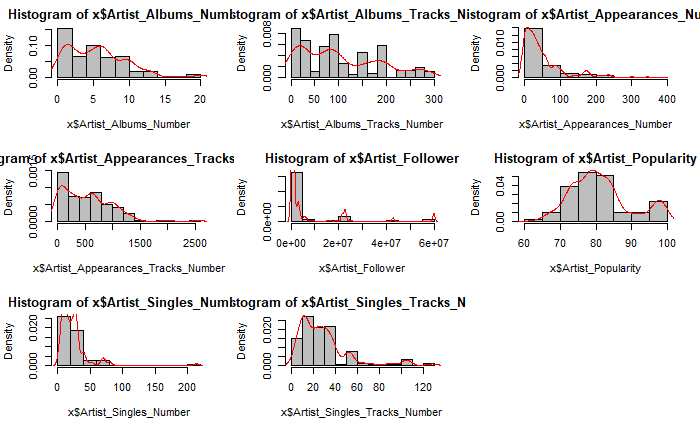

```r
hist(x$Streams, probability = TRUE, col = "gray")
lines(density(x$Streams), col = "red")
```

```r
par(mfrow=c(3,3))
hist(x$Track_Duration_ms, probability = TRUE, col = "gray")
lines(density(x$Track_Duration_ms), col = "red")
```

```r
hist(x$Track_Popularity, probability = TRUE, col = "gray")
lines(density(x$Track_Popularity), col = "red")
```

```r
hist(x$Title_Artist_Google_searches_11m, probability = TRUE, col = "gray")
lines(density(x$Title_Artist_Google_searches_11m), col = "red")
```

```r
hist(x$Title_Artist_Youtube_searches_11m, probability = TRUE, col = "gray")
lines(density(x$Title_Artist_Youtube_searches_11m), col = "red")
```

```r
hist(x$Title_Google_searches_11m, probability = TRUE, col = "gray")
lines(density(x$Title_Google_searches_11m), col = "red")
```

```r
hist(x$Total_tracks, probability = TRUE, col = "gray")
lines(density(x$Total_tracks), col = "red")
```

```r
hist(x$Artist_Google_searches_11m, probability = TRUE, col = "gray")
lines(density(x$Artist_Google_searches_11m), col = "red")
```

```r
hist(x$Artist_Youtube_searches_11m, probability = TRUE, col = "gray")
lines(density(x$Artist_Youtube_searches_11m), col = "red")
```

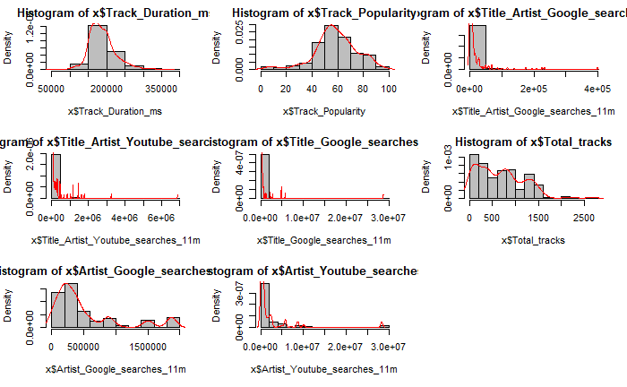

```r
hist(x$commentCount, probability = TRUE, col = "gray")
lines(density(x$commentCount, na.rm = TRUE), col = "red")
```

```r
par(mfrow=c(1,2))
hist(x$dislikeCount, probability = TRUE, col = "gray")
lines(density(x$dislikeCount), col = "red")
```

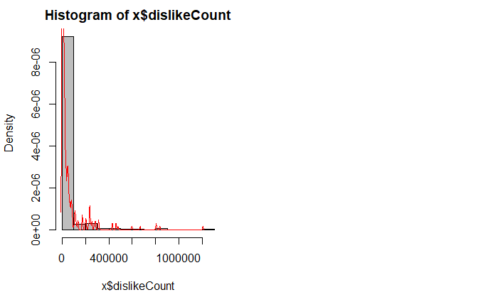

```r
hist(log(x$viewsCount), probability = TRUE, col = "gray")
lines(density(log(x$viewsCount), na.rm = TRUE), col = "red")
```

```r
#hist(x$viewsCount, probability = TRUE, col = "gray")
#lines(density(x$viewsCount, na.rm = TRUE), col = "red")
```

Distribution testing

1. Normality

```r
strictly_positive_variables <- c('Artist_Follower', 'Artist_Popularity', 'Artist_Singles_Number',
                                 'Artist_Singles_Tracks_Number' , 'Streams', 'Track_Duration_ms', 'Total_tracks',
                                 'viewsCount', 'Artist_Google_searches_11m', 'Artist_Youtube_searches_11m')
summary(select(x, strictly_positive_variables))
```

```
 Artist_Follower    Artist_Popularity Artist_Singles_Number Artist_Singles_Tracks_Number    Streams
 Min.   :    9449   Min.   :60.00     Min.   :  3.00        Min.   :  4.00               Min.   :    43688
 1st Qu.:  575873   1st Qu.:74.00     1st Qu.: 11.00        1st Qu.: 12.00               1st Qu.:   799953
 Median :  889326   Median :80.00     Median : 19.00        Median : 26.00               Median :  3033628
 Mean   : 5710132   Mean   :81.22     Mean   : 23.18        Mean   : 29.01               Mean   :  8595051
 3rd Qu.: 3129993   3rd Qu.:84.25     3rd Qu.: 29.00        3rd Qu.: 35.00               3rd Qu.: 11802780
 Max.   :59828212   Max.   :99.00     Max.   :213.00        Max.   :128.00               Max.   :106824437
 Track_Duration_ms  Total_tracks      viewsCount        Artist_Google_searches_11m Artist_Youtube_searches_11m
 Min.   : 51104    Min.   :   5.0   Min.   :3.290e+03   Min.   :      1            Min.   :      10
 1st Qu.:162634    1st Qu.: 239.0   1st Qu.:1.698e+06   1st Qu.: 183522            1st Qu.:  270454
 Median :182656    Median : 678.0   Median :6.880e+06   Median : 336545            Median :  504090
 Mean   :187680    Mean   : 661.6   Mean   :7.298e+07   Mean   : 513368            Mean   : 2179428
 3rd Qu.:204396    3rd Qu.: 955.8   3rd Qu.:3.175e+07   3rd Qu.: 608772            3rd Qu.: 1705727
 Max.   :361946    Max.   :2699.0   Max.   :4.641e+09   Max.   :1871000            Max.   :28298181
```

```r
for (i in 1:length(strictly_positive_variables)){

  column_name <- strictly_positive_variables[i]

  sub_df <- numeric_x[column_name]
  sub_df <- as.numeric(as.character(unlist(sub_df[[1]])))

  test_statistic <- ks.test(sub_df, "pnorm", mean=mean(sub_df), sd=sd(sub_df))$statistic
  critical_value <- 1.3581 / sqrt (length(sub_df))

  if (test_statistic > critical_value) {
message(paste(" ", column_name , " is not approximately normally distributed.", test_statistic, critical_value))
} else {
message(paste(" ", column_name , " is approximately normally distributed!", test_statistic, critical_value))
}}
```

[output not shown]

None of the strictly positive variables in their base specification passes the KS test.

2. Standard normality

```r
numeric_x_scaled <- scale(numeric_x, center = TRUE, scale = TRUE)
numeric_x_scaled <- as.data.frame(numeric_x_scaled)
par(mfrow=c(3,3))
hist(numeric_x_scaled$Artist_Albums_Number, probability = TRUE, col = "gray")
lines(density(numeric_x_scaled$Artist_Albums_Number), col = "red")
```

```r
hist(numeric_x_scaled$Artist_Albums_Tracks_Number, probability = TRUE, col = "gray")
lines(density(numeric_x_scaled$Artist_Albums_Tracks_Number), col = "red")
```

```r
hist(numeric_x_scaled$Artist_Appearances_Number, probability = TRUE, col = "gray")
lines(density(numeric_x_scaled$Artist_Appearances_Number), col = "red")
```

```r
hist(numeric_x_scaled$Artist_Appearances_Tracks_Number, probability = TRUE, col = "gray")
lines(density(numeric_x_scaled$Artist_Appearances_Tracks_Number), col = "red")
```

```r
hist(numeric_x_scaled$Artist_Follower, probability = TRUE, col = "gray")
lines(density(numeric_x_scaled$Artist_Follower), col = "red")
```

```r
hist(numeric_x_scaled$Artist_Popularity, probability = TRUE, col = "gray")
lines(density(numeric_x_scaled$Artist_Popularity), col = "red")
```

```r
hist(numeric_x_scaled$Artist_Singles_Number, probability = TRUE, col = "gray")
lines(density(numeric_x_scaled$Artist_Singles_Number), col = "red")
```

```r
hist(numeric_x_scaled$Artist_Singles_Tracks_Number, probability = TRUE, col = "gray")
lines(density(numeric_x_scaled$Artist_Singles_Tracks_Number), col = "red")
```

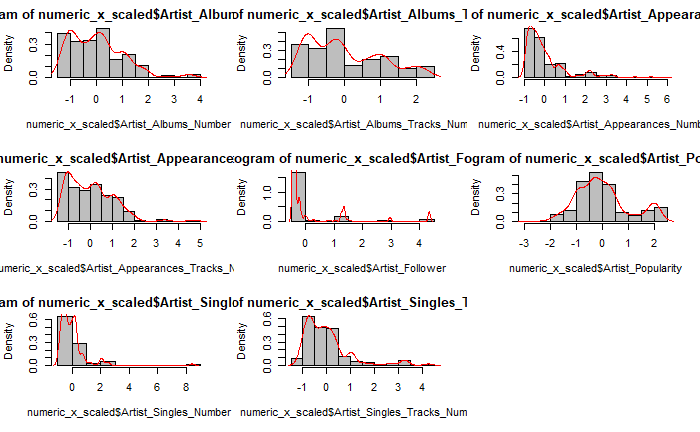

```r
hist(numeric_x_scaled$Streams, probability = TRUE, col = "gray")
lines(density(numeric_x_scaled$Streams), col = "red")
```

```r
par(mfrow=c(3,3))
hist(numeric_x_scaled$Track_Duration_ms, probability = TRUE, col = "gray")
lines(density(numeric_x_scaled$Track_Duration_ms), col = "red")
```

```r
hist(numeric_x_scaled$Track_Popularity, probability = TRUE, col = "gray")
lines(density(numeric_x_scaled$Track_Popularity), col = "red")
```

```r
hist(numeric_x_scaled$Title_Artist_Google_searches_11m, probability = TRUE, col = "gray")
lines(density(numeric_x_scaled$Title_Artist_Google_searches_11m), col = "red")
```

```r
hist(numeric_x_scaled$Title_Artist_Youtube_searches_11m, probability = TRUE, col = "gray")
lines(density(numeric_x_scaled$Title_Artist_Youtube_searches_11m), col = "red")
```

```r
hist(numeric_x_scaled$Title_Google_searches_11m, probability = TRUE, col = "gray")
lines(density(numeric_x_scaled$Title_Google_searches_11m), col = "red")
```

```r
hist(numeric_x_scaled$Total_tracks, probability = TRUE, col = "gray")
lines(density(numeric_x_scaled$Total_tracks), col = "red")
```

```r
hist(numeric_x_scaled$Artist_Google_searches_11m, probability = TRUE, col = "gray")
lines(density(numeric_x_scaled$Artist_Google_searches_11m), col = "red")
```

```r
hist(numeric_x_scaled$Artist_Youtube_searches_11m, probability = TRUE, col = "gray")
lines(density(numeric_x_scaled$Artist_Youtube_searches_11m), col = "red")
```

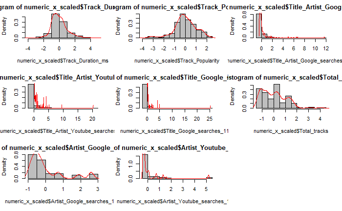

```r
hist(numeric_x_scaled$commentCount, probability = TRUE, col = "gray")
lines(density(numeric_x_scaled$commentCount, na.rm = TRUE), col = "red")
```

```r
par(mfrow=c(1,2))
hist(numeric_x_scaled$dislikeCount, probability = TRUE, col = "gray")
lines(density(numeric_x_scaled$dislikeCount), col = "red")
```

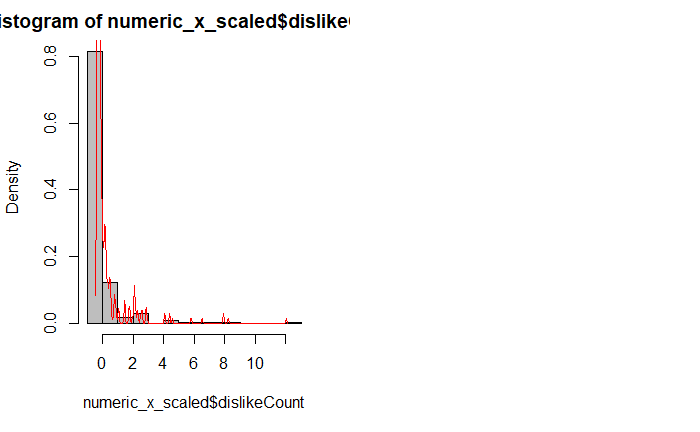

```r
hist(log(x$viewsCount), probability = TRUE, col = "gray")
lines(density(log(x$viewsCount)), col = "red")
```

```r
for (i in 1:length(strictly_positive_variables)){

  column_name <- strictly_positive_variables[i]

  sub_df <- numeric_x_scaled[column_name]
  sub_df <- as.numeric(as.character(unlist(sub_df[[1]])))

  test_statistic <- ks.test(sub_df, "pnorm", mean=mean(sub_df), sd=sd(sub_df))$statistic
  critical_value <- 1.3581 / sqrt (length(sub_df))

  if (test_statistic > critical_value) {
message(paste(" Z-transformed ", column_name , " is not approximately normally distributed.", test_statistic, critical_value))
} else {
message(paste(" Z-transformed ", column_name , " is approximately normally distributed!", test_statistic, critical_value))
}}
```

[output not shown]

Again, none of the z-transformed variables is approximately normally distributed, however only Track_Duration_ms is close to the critical value at $\alpha$ = 0.05.

3. Log-normality

```r
log_numeric_x <- log(numeric_x)
par(mfrow=c(3,3))
hist(log_numeric_x$Artist_Albums_Number, probability = TRUE, col = "gray")
lines(density(log_numeric_x$Artist_Albums_Number), col = "red")
```

```r
hist(log_numeric_x$Artist_Albums_Tracks_Number, probability = TRUE, col = "gray")
lines(density(log_numeric_x$Artist_Albums_Tracks_Number), col = "red")
```

```r
hist(log_numeric_x$Artist_Appearances_Number, probability = TRUE, col = "gray")
lines(density(log_numeric_x$Artist_Appearances_Number), col = "red")
```

```r
hist(log_numeric_x$Artist_Appearances_Tracks_Number, probability = TRUE, col = "gray")
lines(density(log_numeric_x$Artist_Appearances_Tracks_Number), col = "red")
```

```r
hist(log_numeric_x$Artist_Follower, probability = TRUE, col = "gray")
lines(density(log_numeric_x$Artist_Follower), col = "red")
```

```r
hist(log_numeric_x$Artist_Popularity, probability = TRUE, col = "gray")
lines(density(log_numeric_x$Artist_Popularity), col = "red")
```

```r
hist(log_numeric_x$Artist_Singles_Number, probability = TRUE, col = "gray")
lines(density(log_numeric_x$Artist_Singles_Number), col = "red")
```

```r
hist(log_numeric_x$Artist_Singles_Tracks_Number, probability = TRUE, col = "gray")
lines(density(log_numeric_x$Artist_Singles_Tracks_Number), col = "red")
```

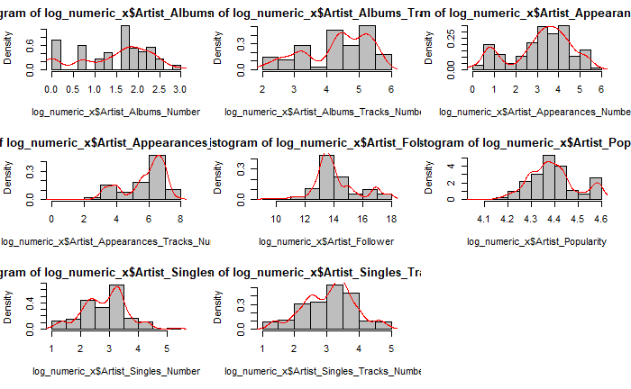

```r
hist(log_numeric_x$Streams, probability = TRUE, col = "gray")
lines(density(log_numeric_x$Streams), col = "red")
```

```r
par(mfrow=c(3,3))
hist(log_numeric_x$Track_Duration_ms, probability = TRUE, col = "gray")
lines(density(log_numeric_x$Track_Duration_ms), col = "red")
```

```r
hist(log_numeric_x$Track_Popularity, probability = TRUE, col = "gray")
lines(density(log_numeric_x$Track_Popularity), col = "red")
```

```r
hist(log_numeric_x$Title_Artist_Google_searches_11m, probability = TRUE, col = "gray")
lines(density(log_numeric_x$Title_Artist_Google_searches_11m), col = "red")
```

```r
hist(log_numeric_x$Title_Artist_Youtube_searches_11m, probability = TRUE, col = "gray")
lines(density(log_numeric_x$Title_Artist_Youtube_searches_11m), col = "red")
```

```r
hist(log_numeric_x$Title_Google_searches_11m, probability = TRUE, col = "gray")
lines(density(log_numeric_x$Title_Google_searches_11m), col = "red")
```

```r
hist(log_numeric_x$Total_tracks, probability = TRUE, col = "gray")
lines(density(log_numeric_x$Total_tracks), col = "red")
```

```r
hist(log_numeric_x$Artist_Google_searches_11m, probability = TRUE, col = "gray")
lines(density(log_numeric_x$Artist_Google_searches_11m), col = "red")
```

```r
hist(log_numeric_x$Artist_Youtube_searches_11m, probability = TRUE, col = "gray")
lines(density(log_numeric_x$Artist_Youtube_searches_11m), col = "red")
```

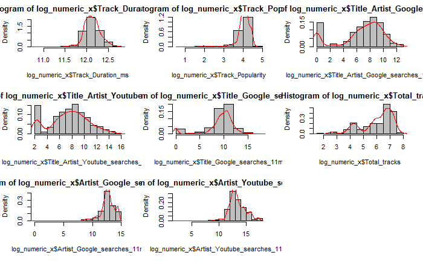

```r
hist(log_numeric_x$commentCount, probability = TRUE, col = "gray")
lines(density(log_numeric_x$commentCount, na.rm = TRUE), col = "red")
```

```r
par(mfrow=c(1,2))
hist(log_numeric_x$dislikeCount, probability = TRUE, col = "gray")
lines(density(log_numeric_x$dislikeCount), col = "red")
```

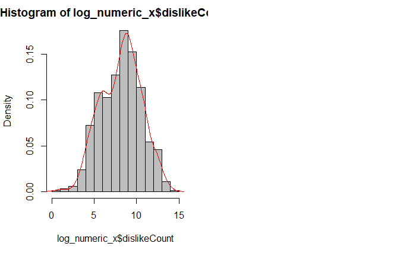

```r
hist(log_numeric_x$viewsCount, probability = TRUE, col = "gray")
lines(density(log_numeric_x$viewsCount), col = "red")
```

```r
for (i in 1:length(strictly_positive_variables)){

  column_name <- strictly_positive_variables[i]

  sub_df <- numeric_x[column_name]
  sub_df <- sub_df[sub_df > 1]
  sub_df <- log(sub_df)
  # sub_df <- as.numeric(as.character(unlist(sub_df[[1]])))

  test_statistic <- ks.test(sub_df, "pnorm", mean=mean(sub_df), sd=sd(sub_df))$statistic
  critical_value <- 1.3581 / sqrt (length(sub_df))

  if (test_statistic > critical_value) {
message(paste(" Log-transformed ", column_name , " is not approximately normally distributed.", test_statistic, critical_value))
} else {
message(paste(" Log-ransformed ", column_name , " is approximately normally distributed!", test_statistic, critical_value))
}}
```

[output not shown]

$H_0$: two variables are jointly normal distributed $H_1$: two variables are not jointly normal distributed

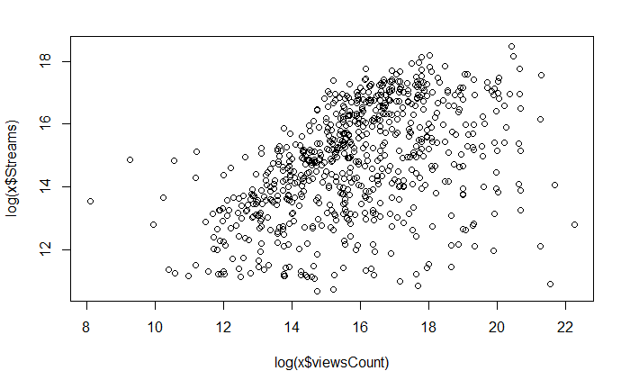

```r
plot(log(x$viewsCount), log(x$Streams))
```

```r
bivariate_df <- select(log_numeric_x, c('Streams', 'viewsCount'))
# install.packages("MVN")
library("MVN")
mvn(bivariate_df, mvnTest = "mardia")$multivariateNormality # Not jointly normal
```

| Test | Statistic | p value | Result |
| --- | --- | --- | --- |
| Mardia Skewness | 125.482980981752 | 3.59864584165554e-26 | NO |
| Mardia Kurtosis | 1.91258360408705 | 0.055801380314662 | YES |
| MVN | NA | NA | NO |

```r
mvn(bivariate_df, mvnTest = "hz")$multivariateNormality # Not jointly normal
```

| Test | HZ | p value | MVN |
| --- | --- | --- | --- |
| Henze-Zirkler | 9.570169 | 0 | NO |

```r
mvn(bivariate_df, mvnTest = "royston")$multivariateNormality #
```

| Test | H | p value | MVN |
| --- | --- | --- | --- |
| Royston | 37.26924 | 8.25193e-09 | NO |

```r
mvn(bivariate_df, mvnTest = "energy")$multivariateNormality
```

| Test | Statistic | p value | MVN |
| --- | --- | --- | --- |
| E-statistic | 9.542325 | 0 | NO |

Result: all tests reject the Null hypothesis that the two variables log-Streams and log-viewsCount are jointly normally distributed. Hence, Steiger’s Z test cannot be meaningfully conducted. All results displayed in the correlogram are thefore to be treated with caution.

4. Box-Cox transformations

```r
library("psych")
library("car")
ksD <- function (p, x) {
  y <- bcPower(x, p)
  ks.test(y, "pnorm", mean=mean(y), sd=sd(y))$statistic
}
oldw <- getOption("warn")
options(warn = -1)
min_values <- c()
for (column_index in 1:length(strictly_positive_variables)){

  column_name <- strictly_positive_variables[column_index]

  x_sub <- as.numeric(x[[paste(column_name)]])

  result <- optimize(ksD, c(-5,5), x=x_sub)

  min_values[column_index] <- result$minimum

  message(paste(column_index, ', minimum value is: ', result$minimum))

}
```

[output not shown]

```r
options(warn = oldw)
```

Box-Cox transformations

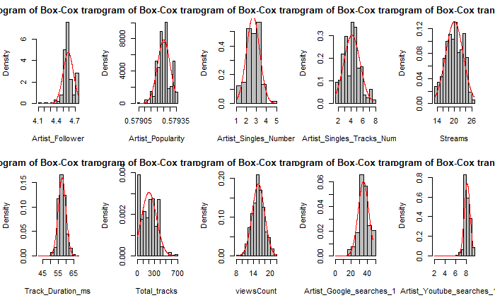

```r
par(mfrow=c(2,5))
column_index <- 1
column_name <- strictly_positive_variables[column_index]
x_sub <- as.numeric(x[[paste(column_name)]])
Artist_Follower_trans <- bcPower(x_sub, min_values[column_index])
column_index <- 2
column_name <- strictly_positive_variables[column_index]
x_sub <- as.numeric(x[[paste(column_name)]])
Artist_Popularity_trans <- bcPower(x_sub, min_values[column_index])
column_index <- 3
column_name <- strictly_positive_variables[column_index]
x_sub <- as.numeric(x[[paste(column_name)]])
Artist_Singles_Number_trans <- bcPower(x_sub, min_values[column_index])
column_index <- 4
column_name <- strictly_positive_variables[column_index]
x_sub <- as.numeric(x[[paste(column_name)]])
Artist_Singles_Tracks_Number_trans <- bcPower(x_sub, min_values[column_index])
column_index <- 5
column_name <- strictly_positive_variables[column_index]
x_sub <- as.numeric(x[[paste(column_name)]])
Streams_trans <- bcPower(x_sub, min_values[column_index])
column_index <- 6
column_name <- strictly_positive_variables[column_index]
x_sub <- as.numeric(x[[paste(column_name)]])
Track_Duration_ms_trans <- bcPower(x_sub, min_values[column_index])
column_index <- 7
column_name <- strictly_positive_variables[column_index]
x_sub <- as.numeric(x[[paste(column_name)]])
Total_tracks_trans <- bcPower(x_sub, min_values[column_index])
column_index <- 8
column_name <- strictly_positive_variables[column_index]
x_sub <- as.numeric(x[[paste(column_name)]])
viewsCount_trans <- bcPower(x_sub, min_values[column_index])
column_index <- 9
column_name <- strictly_positive_variables[column_index]
x_sub <- as.numeric(x[[paste(column_name)]])
Artist_Google_searches_11m_trans <- bcPower(x_sub, min_values[column_index])
column_index <- 10
column_name <- strictly_positive_variables[column_index]
x_sub <- as.numeric(x[[paste(column_name)]])
Artist_Youtube_searches_11m_trans <- bcPower(x_sub, min_values[column_index])
hist_trans_list <- list(Artist_Follower_trans, Artist_Popularity_trans, Artist_Singles_Number_trans,
                     Artist_Singles_Tracks_Number_trans, Streams_trans, Track_Duration_ms_trans, Total_tracks_trans,
                     viewsCount_trans, Artist_Google_searches_11m_trans, Artist_Youtube_searches_11m_trans)
for (trans_index in 1:length(hist_trans_list)){

  column_name <- strictly_positive_variables[trans_index]

  selected_trans <- hist_trans_list[trans_index]
  selected_trans <- as.numeric(as.character(unlist(selected_trans[[1]])))

  hist(selected_trans, col = "gray", probability = TRUE, main = "Histogram of Box-Cox transformed", xlab = column_name)
  points(seq(min(selected_trans), max(selected_trans), length.out = 500),
       dnorm(seq(min(selected_trans), max(selected_trans), length.out = 500),
             mean(selected_trans),sd(selected_trans)), type = "l", col = "red")

  test_statistic <- ks.test(selected_trans, "pnorm", mean=mean(selected_trans), sd=sd(selected_trans))$statistic
  critical_value <- 1.3581 / sqrt (length(selected_trans))

  if (test_statistic > critical_value) {
message(paste("Transformed ", column_name , " is not approximately normally distributed.", test_statistic, critical_value))
} else {
message(paste("Transformed ", column_name , " is approximately normally distributed!", test_statistic, critical_value))
}}
```

```r
#test_statistic <- ks.test(Artist_Follower_trans, "pnorm", mean=mean(Artist_Follower_trans), sd=sd(Artist_Follower_trans))$statistic
#critical_value <- 1.3581 / sqrt (length(x_sub))
#if (test_statistic > critical_value) {
#message(paste("Transformed ", column_name , " is not approximately normally distributed.", test_statistic, critical_value))
#} else {
#message(paste("Transformed ", column_name , " is approximately normally distributed!", test_statistic, critical_value))
#}
```

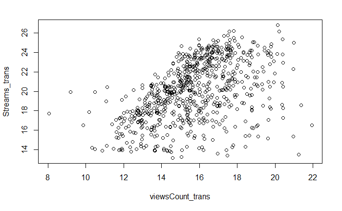

```r
plot(viewsCount_trans, Streams_trans)
```

```r
bivariate_df <- data.frame(viewsCount_trans, Streams_trans)
mvn(bivariate_df, mvnTest = "mardia")$multivariateNormality # Not jointly normal
```

| Test | Statistic | p value | Result |
| --- | --- | --- | --- |
| Mardia Skewness | 117.602845502251 | 1.73611339400134e-24 | NO |
| Mardia Kurtosis | 1.40217211324614 | 0.160863856949058 | YES |
| MVN | NA | NA | NO |

```r
mvn(bivariate_df, mvnTest = "hz")$multivariateNormality # Not jointly normal
```

| Test | HZ | p value | MVN |
| --- | --- | --- | --- |
| Henze-Zirkler | 8.825176 | 0 | NO |

```r
mvn(bivariate_df, mvnTest = "royston")$multivariateNormality #
```

| Test | H | p value | MVN |
| --- | --- | --- | --- |
| Royston | 32.84475 | 7.5373e-08 | NO |

```r
mvn(bivariate_df, mvnTest = "energy")$multivariateNormality
```

| Test | Statistic | p value | MVN |
| --- | --- | --- | --- |
| E-statistic | 8.66207 | 0 | NO |

Result: all tests reject the Null hypothesis that the two variables optimal Box-Cox-Streams and optimal Box-Cox-viewsCount are jointly normally distributed.

Table by genre

```r
table(x$Genre)
```

```
  dance     edm Hip Hop   house   latin   metal     pop     r&b     rap    rock
      4       8     411      13       2      11     140       3     126       2
```

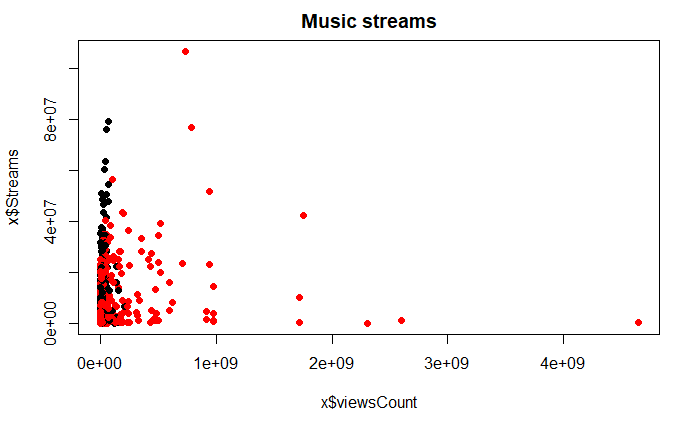

```r
##1
col <- ifelse(x$Genre == "Hip Hop", "black", "red")
plot(x$viewsCount, x$Streams, main="Music streams", pch=19, col=col)
```

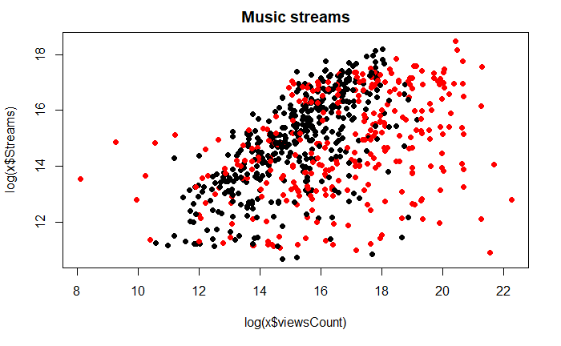

```r
plot(log(x$viewsCount), log(x$Streams), main="Music streams", pch=19, col=col)
```

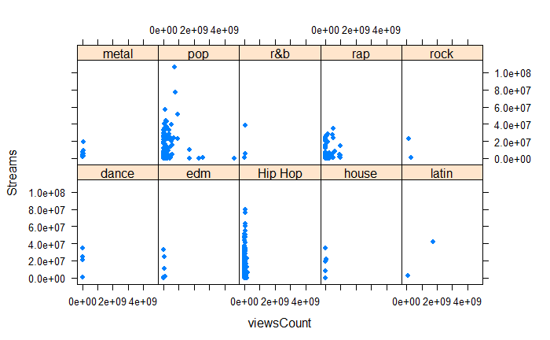

```r
library("lattice")
xyplot(Streams~viewsCount|Genre, data=x, pch=19)
```

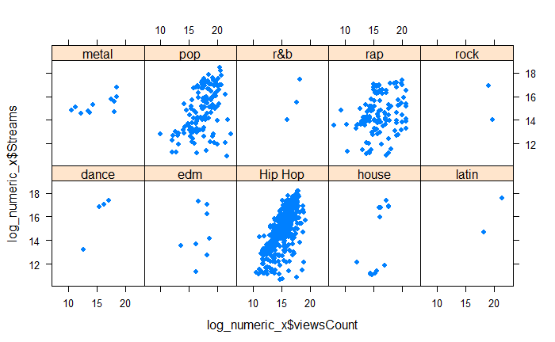

```r
xyplot(log_numeric_x$Streams~log_numeric_x$viewsCount|x$Genre, pch=19)
```

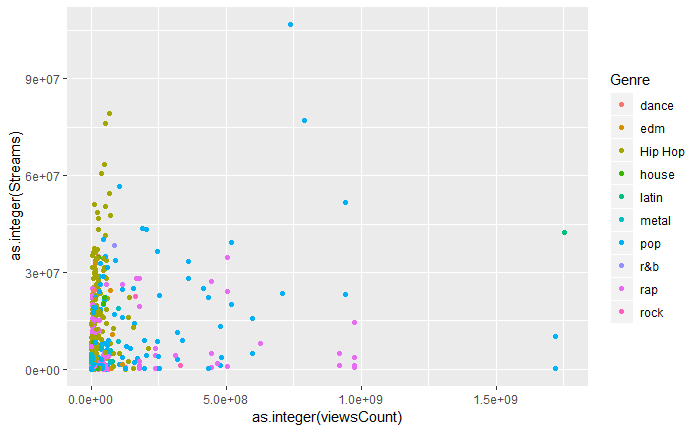

```r
library("ggplot2")
d <-ggplot(x, aes(x=as.integer(viewsCount), y=as.integer(Streams), colour=Genre))
d + geom_point(shape=19)
```

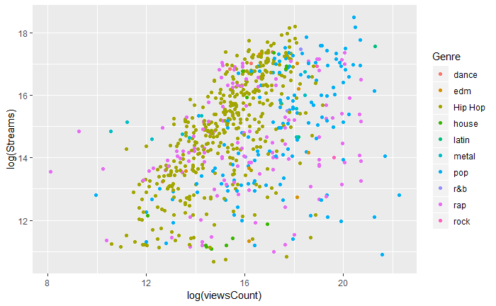

```r
d <-ggplot(x, aes(x=log(viewsCount), y=log(Streams), colour=Genre))
d + geom_point(shape=19)
```

Using sunflower plot to overcome problem of overplotting.

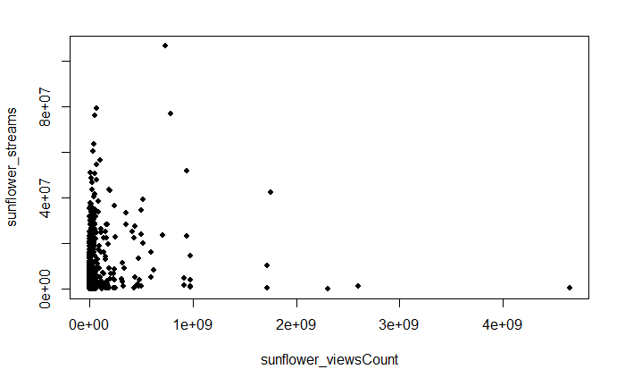

```r
sunflower_viewsCount <- 2*round(x$viewsCount/2)
sunflower_streams  <- 2*round(x$Streams/2)
sunflowerplot(sunflower_streams~sunflower_viewsCount)
```

```r
library("Rmpfr")
# (one <- mpfr(1, 120))
cor <- cor(numeric_x)
drop.cor_cols <- c('Artist_Compilations_Number', 'Artist_Compilations_Tracks_Number')
numeric_cor_x <- select(numeric_x, -one_of(drop.cor_cols))
numeric_cor_x$viewsCount <- as.numeric(numeric_cor_x$viewsCount)
str(numeric_cor_x)
```

```
'data.frame':   720 obs. of  22 variables:
 $ Artist_Albums_Number             : int  0 0 1 1 1 1 1 1 1 1 ...
 $ Artist_Albums_Tracks_Number      : int  0 0 8 8 8 8 8 8 8 8 ...
 $ Artist_Appearances_Number        : int  9 9 2 2 2 2 2 2 2 2 ...
 $ Artist_Appearances_Tracks_Number : int  502 502 30 30 30 30 30 30 30 30 ...
 $ Artist_Follower                  : int  713401 713401 601346 601346 601346 601346 601346 601346 601346 601346 ...
 $ Artist_Popularity                : int  91 91 83 83 83 83 83 83 83 83 ...
 $ Artist_Singles_Number            : int  3 3 15 15 15 15 15 15 15 15 ...
 $ Artist_Singles_Tracks_Number     : int  10 10 15 15 15 15 15 15 15 15 ...
 $ Streams                          : int  106824437 2327995 79193552 54619683 48552840 46784729 43436284 35294439 30904982 28153458 ...
 $ Track_Duration_ms                : int  209754 200755 157093 158853 176066 163146 139693 191760 176200 159533 ...
 $ Track_Popularity                 : int  76 72 78 77 73 75 73 75 69 69 ...
 $ Title_Artist_Google_searches_11m : int  20904 572 8880 8880 1975 1156 3260 10880 220 568 ...
 $ Title_Artist_Youtube_searches_11m: int  308911 7320 7660 7660 1530 990 2240 7915 154 441 ...
 $ Title_Google_searches_11m        : int  1288732 2799 4805454 4805454 47025 33165 47709 45925 8977 7568 ...
 $ Title_Youtube_searches_11m       : int  18353181 33600 3446454 3446454 32325 28872 38436 31975 5931 6349 ...
 $ Total_tracks                     : int  512 512 53 53 53 53 53 53 53 53 ...
 $ Artist_Google_searches_11m       : int  299212 299212 1468281 1468281 1468281 1468281 1468281 1468281 1468281 1468281 ...
 $ Artist_Youtube_searches_11m      : int  2451500 2451500 1076400 1076400 1076400 1076400 1076400 1076400 1076400 1076400 ...
 $ commentCount                     : int  172604 2272 22183 22183 13376 10741 8662 303 5795 4485 ...
 $ dislikeCount                     : int  317322 3194 27802 27802 11440 12957 10493 605 5333 4287 ...
 $ likeCount                        : int  7424686 109395 748270 748270 385252 378780 299481 24361 211469 156222 ...
 $ viewsCount                       : num  7.39e+08 1.03e+07 6.70e+07 6.70e+07 2.22e+07 ...
```

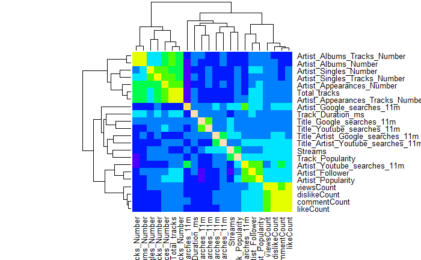

```r
clean_cor <- cor(numeric_cor_x[complete.cases(numeric_cor_x), ])
heatmap(clean_cor, revC=T, col=topo.colors(10))
```

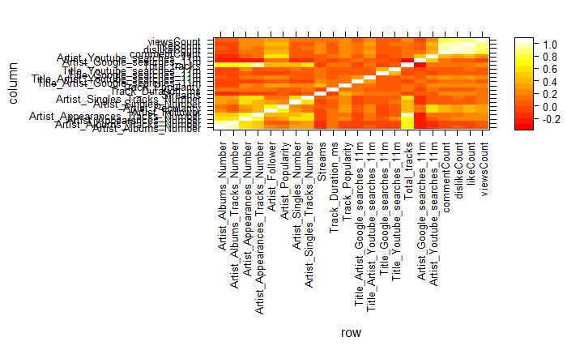

```r
library("lattice")
levelplot(clean_cor, scales=list(x=list(rot=90)), aspect = "fill", col.regions=heat.colors(100))
```

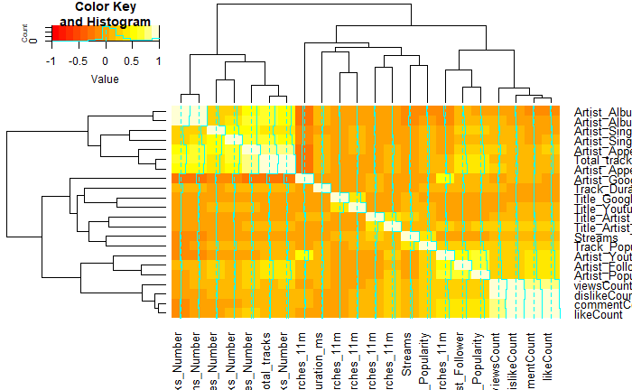

```r
library("gplots")
gplots::heatmap.2(clean_cor, revC=T, na.rm=T)
```

Tests for significance of Bravais-Pearson, Spearman and Kendall correlation coefficients

```r
x$stream_quantile_ind <- 0
stream_quantiles <- quantile(x$Streams, probs = c(0.25, 0.5, 0.75))
streams_q_25 <- stream_quantiles[1]
streams_median <- stream_quantiles[2]
streams_q_75 <- stream_quantiles[3]
x$stream_quantile_ind <- ifelse(x$Streams < streams_q_25, 1, x$stream_quantile_ind + 0)
x$stream_quantile_ind <- ifelse(((x$Streams >= streams_q_25) & (x$Streams < streams_median)), 2, x$stream_quantile_ind + 0)
x$stream_quantile_ind <- ifelse(((x$Streams >= streams_median) & (x$Streams < streams_q_75)), 3, x$stream_quantile_ind + 0)
x$stream_quantile_ind <- ifelse((x$Streams >= streams_q_75), 4, x$stream_quantile_ind + 0)
# bottom_25 <- subset(x , Streams < q_25)
# top_50_75 <- subset(x, Streams >= q_25 & Streams < median)
# top_25_50 <- subset(x , Streams >= median & Streams < q_75)
# top_25 <- subset(x, Streams >= q_75)
x$stream_quantile_ind <- as.factor(x$stream_quantile_ind)
x$Genre <- as.factor(x$Genre)
tab<-table(x$Genre, x$stream_quantile_ind)
tab
```

```
            1   2   3   4
  dance     1   0   0   3
  edm       3   2   1   2
  Hip Hop  96 100 116  99
  house     7   0   1   5
  latin     0   1   0   1
  metal     0   5   5   1
  pop      42  22  34  42
  r&b       0   1   1   1
  rap      31  48  22  25
  rock      0   1   0   1
```

```r
# critical Chi^2 value (df= 27): 40.11
chisq.test(tab)
```

```
Chi-Quadrat-Approximation kann inkorrekt sein
```

```
    Pearson's Chi-squared test

data:  tab
X-squared = 52.499, df = 27, p-value = 0.002312
```

```r
chisq.test(tab, simulate.p.value = TRUE)
```

```
    Pearson's Chi-squared test with simulated p-value (based on 2000 replicates)

data:  tab
X-squared = 52.499, df = NA, p-value = 0.001999
```

```r
library("vcd")
assocstats(tab)
```

```
                    X^2 df   P(> X^2)
Likelihood Ratio 60.166 27 0.00025092
Pearson          52.499 27 0.00231197

Phi-Coefficient   : NA
Contingency Coeff.: 0.261
Cramer's V        : 0.156
```

The p-value is smaller than the confidence level $\alpha$ = 0.05, hence we reject the Null hypothesis of no independence and conclude that there exists a dependence between the songs’ genre and their placement within the four quantile ranges of the distribution of their amount of streams. Cramer’s V (~0.16) suggests that there is a weak dependence between the ranking of a track and its genre.

```r
x$viewsCount_quantile_ind <- 0
viewsCount_quantiles <- quantile(x$viewsCount, probs = c(0.25, 0.5, 0.75))
viewsCount_q_25 <- viewsCount_quantiles[1]
viewsCount_median <- viewsCount_quantiles[2]
viewsCount_q_75 <- viewsCount_quantiles[3]
x$viewsCount_quantile_ind <- ifelse(x$viewsCount < viewsCount_q_25, 1, x$viewsCount_quantile_ind + 0)
x$viewsCount_quantile_ind <- ifelse(((x$viewsCount >= viewsCount_q_25) & (x$viewsCount < viewsCount_median)), 2, x$viewsCount_quantile_ind + 0)
x$viewsCount_quantile_ind <- ifelse(((x$viewsCount >= viewsCount_median) & (x$viewsCount < viewsCount_q_75)), 3, x$viewsCount_quantile_ind + 0)
x$viewsCount_quantile_ind <- ifelse((x$viewsCount >= viewsCount_q_75), 4, x$viewsCount_quantile_ind + 0)
# bottom_25 <- subset(x , Streams < q_25)
# top_50_75 <- subset(x, Streams >= q_25 & Streams < median)
# top_25_50 <- subset(x , Streams >= median & Streams < q_75)
# top_25 <- subset(x, Streams >= q_75)
x$viewsCount_quantile_ind <- as.factor(x$viewsCount_quantile_ind)
tab<-table(x$Genre, x$viewsCount_quantile_ind)
tab
```

```
            1   2   3   4
  dance     1   1   2   0
  edm       1   0   3   4
  Hip Hop 127 125 116  43
  house     1   5   5   2
  latin     0   0   0   2
  metal     6   0   0   5
  pop      13  18  27  82
  r&b       0   0   1   2
  rap      31  30  27  38
  rock      0   0   0   2
```

```r
# critical Chi^2 value (df= 27): 40.11
chisq.test(tab)
```

```
Chi-Quadrat-Approximation kann inkorrekt sein
```

```
    Pearson's Chi-squared test

data:  tab
X-squared = 173.9, df = 27, p-value < 2.2e-16
```

```r
chisq.test(tab, simulate.p.value = TRUE)
```

```
    Pearson's Chi-squared test with simulated p-value (based on 2000 replicates)

data:  tab
X-squared = 173.9, df = NA, p-value = 0.0004998
```

```r
library("vcd")
assocstats(tab)
```

```
                    X^2 df P(> X^2)
Likelihood Ratio 178.58 27        0
Pearson          173.90 27        0

Phi-Coefficient   : NA
Contingency Coeff.: 0.441
Cramer's V        : 0.284
```

The p-value is smaller than the confidence level $\alpha$ = 0.05, hence we reject the Null hypothesis of no independence and conclude that there exists a dependence between the songs’ genre and their placement within the four quantile ranges of the distribution of their views on Youtube. Cramer’s V (~0.3) suggests that there is a semi-weak dependence between the ranking of a music video and its genre.

```r
x$Follower_median_ind <- 0
Follower_median <- median(x$Artist_Follower)
x$Follower_median_ind <- ifelse(x$Artist_Follower < Follower_median, 0, 1)
x$Follower_median_ind <- as.factor(x$Follower_median_ind)
tab<-table(x$Genre, x$Follower_median_ind)
tab
```

```
            0   1
  dance     4   0
  edm       3   5
  Hip Hop 241 170
  house     1  12
  latin     0   2
  metal     0  11
  pop      59  81
  r&b       0   3
  rap      31  95
  rock      0   2
```

```r
# critical Chi^2 value (df= 27): 40.11
chisq.test(tab)
```

```
Chi-Quadrat-Approximation kann inkorrekt sein
```

```
    Pearson's Chi-squared test

data:  tab
X-squared = 77.853, df = 9, p-value = 4.31e-13
```

```r
chisq.test(tab, simulate.p.value = TRUE)
```

```
    Pearson's Chi-squared test with simulated p-value (based on 2000 replicates)

data:  tab
X-squared = 77.853, df = NA, p-value = 0.0004998
```

```r
assocstats(tab)
```

```
                    X^2 df   P(> X^2)
Likelihood Ratio 89.396  9 2.1094e-15
Pearson          77.853  9 4.3099e-13

Phi-Coefficient   : NA
Contingency Coeff.: 0.312
Cramer's V        : 0.329
```

```r
# kendall's tau for stream quantile and follower median
ab2 <- na.omit(cbind(x$stream_quantile_ind, x$Follower_median_ind))
library("ryouready")
ord.tau(table(ab2[,1], ab2[,2]))
```

```
Kendall's (and Stuart's) Tau statistics
    Tau-b: -0.090
    Tau-c: -0.110
```

```r
cor(as.numeric(x$stream_quantile_ind), as.numeric(x$Follower_median_ind), method = "kendall") # identical result
```

```
[1] -0.08974063
```

```r
cor.test(as.numeric(x$stream_quantile_ind), as.numeric(x$Follower_median_ind), method="kendall")
```

```
    Kendall's rank correlation tau

data:  as.numeric(x$stream_quantile_ind) and as.numeric(x$Follower_median_ind)
z = -2.636, p-value = 0.008389
alternative hypothesis: true tau is not equal to 0
sample estimates:
        tau
-0.08974063
```

The relationship between genre and whether the track’s artist’s follower count is smaller than the median value (=0) or not (=1) appears to be significant and semi-weak, as suggested by the $\chi^2$-Test and Cramer’s V.

The relationship between stream quantiles and the follower > median indicator variable appears to be negative (about -0.09) and is significant at the $\alpha$ = 0.01 level.

Let’s see whether there exists an ordinal relationship between the placement of streams within the distributional range and the placement of the corresponding music video’s views:

```r
ab2 <- na.omit(cbind(x$stream_quantile_ind, x$viewsCount_quantile_ind))
nrow(ab2)*(nrow(ab2)-1)/2
```

```
[1] 258840
```

```r
#
ind <- order(ab2[,1], ab2[,2])
ab2 <- ab2[ind,]
#b
C <- D <- Tx <- Ty <- Txy <- 0
for (i in 1:(nrow(ab2)-1)) {
  if (i%%100==0) cat(i, "\n")
  for(j in (i+1):nrow(ab2)) {
    if (ab2[i,1]==ab2[j,1]) {
      if (ab2[i,2]==ab2[j,2]) {
        Txy <- Txy+1
      } else {
        Tx <- Tx+(ab2[i,2]<ab2[j,2])
      }
    } else {
      if (ab2[i,2]==ab2[j,2]) Ty <- Ty+1
      if (ab2[i,2]<ab2[j,2]) C <- C+1
      if (ab2[i,2]>ab2[j,2]) D <- D+1
    }
  }
}
```

```
100
200
300
400
500
600
700
```

```r
c(C=C, D=D, Tx=Tx, Ty=Ty, Txy=Txy)
```

```
     C      D     Tx     Ty    Txy
115660  35319  43420  43421  21020
```

```r
k_t <- (C - D)/(nrow(ab2)*(nrow(ab2)-1)/2)
k_t # (without ties)
```

```
[1] 0.3103887
```

```r
library("ryouready")
ord.tau(table(ab2[,1], ab2[,2]))
```

```
Kendall's (and Stuart's) Tau statistics
    Tau-b: 0.413
    Tau-c: 0.413
```

```r
cor(as.numeric(x$stream_quantile_ind), as.numeric(x$viewsCount_quantile_ind), method = "kendall") # identical result
```

```
[1] 0.4132778
```

```r
cor.test(as.numeric(x$stream_quantile_ind), as.numeric(x$viewsCount_quantile_ind), method="kendall")
```

```
    Kendall's rank correlation tau

data:  as.numeric(x$stream_quantile_ind) and as.numeric(x$viewsCount_quantile_ind)
z = 13.297, p-value < 2.2e-16
alternative hypothesis: true tau is not equal to 0
sample estimates:
      tau
0.4132778
```

```r
tab<-table(x$stream_quantile_ind, x$viewsCount_quantile_ind)
chisq.test(tab)
```

```
    Pearson's Chi-squared test

data:  tab
X-squared = 230.12, df = 9, p-value < 2.2e-16
```

```r
chisq.test(tab, simulate.p.value = TRUE)
```

```
    Pearson's Chi-squared test with simulated p-value (based on 2000 replicates)

data:  tab
X-squared = 230.12, df = NA, p-value = 0.0004998
```

```r
library("vcd")
assocstats(tab)
```

```
                    X^2 df P(> X^2)
Likelihood Ratio 261.31  9        0
Pearson          230.12  9        0

Phi-Coefficient   : NA
Contingency Coeff.: 0.492
Cramer's V        : 0.326
```

The rank correlation coefficient by Kendall’s Tau (here for a quadratic table) is around 0.41 and the test yields that this coefficient is significant, hence we can conclude that there exists a positive relationship between the placement of streams of a song on Spotify and the placement of views of the corresponding music video on Youtube, meaning a higher rank of the song’s music video in Youtube views is associated with a higher rank inside of Spotify’s streams.

Even if not appropriate since the two variables have an ordinal scale and using $\chi^2$ test for independence would neglect additional information, Cramer’s V (~0.33) states there exists a semi-weak relationship but without inferring anything about the direction of the relationship, only the strength of this relationship. Therefore, Kendall’s Tau gives us the “correct” estimate, indicating the positive relationship between the two ordinal variables.

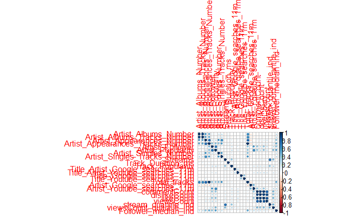

```r
numeric_cor_x$stream_quantile_ind <- as.numeric(x$stream_quantile_ind)
numeric_cor_x$viewsCount_quantile_ind <- as.numeric(x$viewsCount_quantile_ind)
numeric_cor_x$Follower_median_ind <- as.numeric(x$Follower_median_ind)
clean_cor <- cor(numeric_cor_x[complete.cases(numeric_cor_x), ])
library(corrplot)
corrplot(clean_cor, method="circle")
```

[figure not shown]

```r
cor.mtest <- function(mat, ...) {
  mat <- as.matrix(mat)
  n <- ncol(mat)
  p.mat<- matrix(NA, n, n)
  diag(p.mat) <- 0
  for (i in 1:(n - 1)) {
    for (j in (i + 1):n) {
      tmp <- cor.test(mat[, i], mat[, j], ..., method = "kendall")
      p.mat[i, j] <- p.mat[j, i] <- tmp$p.value
    }
  }
  colnames(p.mat) <- rownames(p.mat) <- colnames(mat)
  p.mat
}
# matrix of the p-value of the correlation
p.mat <- cor.mtest(clean_cor)
col <- colorRampPalette(c("#BB4444", "#EE9988", "#FFFFFF", "#77AADD", "#4477AA"))
significance_level <- 0.05
corrplot(clean_cor, method="color", col=col(200),
         type="upper", order="hclust",
         addCoef.col = "black", # Add coefficient of correlation
         tl.col="black", tl.srt=90, #Text label color and rotation
         # Combine with significance
         p.mat = p.mat, sig.level = significance_level, insig = "blank",
         # hide correlation coefficient on the principal diagonal
         diag=FALSE)
```

[figure not shown]

Prediction Reduction Error measures

Goodmann and Kruskals $\lambda$

1. predicting stream quantile without any knowledge about association with view quantiles, just taking the mode as predictor
2. predicting stream quantile with knowledge about track’s corresponding placement in video view distribution

```r
modetab <- function(x, margin=0) {
  if (margin>0) apply(x, margin, max) else max(x)
}
tab2 <- table(numeric_cor_x$stream_quantile_ind,
              numeric_cor_x$viewsCount_quantile_ind, dnn = c("Song streams", "Video views"))
tab2
```

```
            Video views
Song streams  1  2  3  4
           1 95 38 23 24
           2 64 51 39 26
           3 21 68 38 53
           4  0 22 81 77
```

```r
tab <- rowSums(tab2)
message(paste("The mode is equal across all four quantiles of stream distribution, which is", modetab(tab)))
```

```
The mode is equal across all four quantiles of stream distribution, which is 180
```

```r
e1_streams <- sum(tab) - modetab(tab)
message(paste("Without any knowledge about an additional feature other than music streams itself and using the mode across classes as best predictor for class assignment for a new observation, the number of falsely predicted cases would be: ", e1_streams, " or ", e1_streams/sum(tab), "%."))
```

```
Without any knowledge about an additional feature other than music streams itself and using the mode across classes as best predictor for class assignment for a new observation, the number of falsely predicted cases would be:  540  or  0.75 %.
```

```r
e2_streams <- sum(tab2) - sum(modetab(tab2, 2))
message(paste("Now having knowledge about an association between track streams and its video views and using class-internal modes for the additional feature, the number of falsely predicted cases would be: ", e2_streams, " or ", e2_streams/sum(tab), "%, which is already much lower compared to the error rate from predicting without any knowledge about an association. On the other hand, ", sum(tab2)-e2_streams, " or ", (sum(tab2)-e2_streams)/sum(tab2), "% would have been predicted correctly (compared to ", 1-e1_streams/sum(tab), "% if there was no knowledge about video views classes.)"))
```

```
Now having knowledge about an association between track streams and its video views and using class-internal modes for the additional feature, the number of falsely predicted cases would be:  399  or  0.554166666666667 %, which is already much lower compared to the error rate from predicting without…
```

```r
message("For example, the best prediction for a song that resided within the bottom quantile of video views would be that it also resides inside of the bottom quantile of streams as the mode of 95 was found to be from this class. Hence, using the class mode of the lower bottom quantile video views to predict lower bottom quantile streams would yield 95 correct cases but 180-95= 85 misclassified predictions.")
```

```
For example, the best prediction for a song that resided within the bottom quantile of video views would be that it also resides inside of the bottom quantile of streams as the mode of 95 was found to be from this class. Hence, using the class mode of the lower bottom quantile video views to predict…
```

```r
lambda <- (e1_streams - e2_streams)/e1_streams
message(paste("Therefore, Goodmann and Kruskals Lambda is: ", lambda))
```

```
Therefore, Goodmann and Kruskals Lambda is:  0.261111111111111
```

```r
library("ryouready")
nom.lambda(tab2)
```

```
Lambda:
    Columns dependent: 0.236
    Rows dependent: 0.261
    Symmetric: 0.248
```

1. predicting stream quantile without any knowledge about association with genre, just taking the mode as predictor
2. predicting stream quantile with knowledge about track’s genre

```r
tab2 <- table(numeric_cor_x$stream_quantile_ind,
              x$Genre, dnn = c("Song streams", "Genre"))
tab2
```

```
            Genre
Song streams dance edm Hip Hop house latin metal pop r&b rap rock
           1     1   3      96     7     0     0  42   0  31    0
           2     0   2     100     0     1     5  22   1  48    1
           3     0   1     116     1     0     5  34   1  22    0
           4     3   2      99     5     1     1  42   1  25    1
```

```r
tab <- rowSums(tab2)
message(paste("The mode is equal across all four quantiles of stream distribution, which is", modetab(tab)))
```

```
The mode is equal across all four quantiles of stream distribution, which is 180
```

```r
e1_streams <- sum(tab) - modetab(tab)
message(paste("Without any knowledge about an additional feature other than music streams itself and using the mode across classes as best predictor for class assignment for a new observation, the number of falsely predicted cases would be: ", e1_streams, " or ", e1_streams/sum(tab), "%."))
```

```
Without any knowledge about an additional feature other than music streams itself and using the mode across classes as best predictor for class assignment for a new observation, the number of falsely predicted cases would be:  540  or  0.75 %.
```

```r
e2_streams <- sum(tab2) - sum(modetab(tab2, 2))
message(paste("Now having knowledge about an association between track streams and its genre and using class-internal modes for the additional feature, the number of falsely predicted cases would be: ", e2_streams, " or ", e2_streams/sum(tab), "%, which is already much lower compared to the error rate from predicting without any knowledge about an association. On the other hand, ", sum(tab2)-e2_streams, " or ", (sum(tab2)-e2_streams)/sum(tab2), "% would have been predicted correctly (compared to ", 1-e1_streams/sum(tab), "% if there was no knowledge about genre.)"))
```

```
Now having knowledge about an association between track streams and its genre and using class-internal modes for the additional feature, the number of falsely predicted cases would be:  493  or  0.684722222222222 %, which is already much lower compared to the error rate from predicting without any k…
```

```r
message("For example, the best prediction for a song that is from the genre 'Hip-Hop' would be that it resides inside of the 3rd quantile of streams as the mode of 116 was found to be from this class. Hence, using the class mode of the genre 'Hip-Hop' to predict 3rd quantile streams would yield 116 correct cases but 411-116= 295 misclassified predictions.")
```

```
For example, the best prediction for a song that is from the genre 'Hip-Hop' would be that it resides inside of the 3rd quantile of streams as the mode of 116 was found to be from this class. Hence, using the class mode of the genre 'Hip-Hop' to predict 3rd quantile streams would yield 116 correct c…
```

```r
lambda <- (e1_streams - e2_streams)/e1_streams
message(paste("Therefore, Goodmann and Kruskals Lambda is: ", lambda))
```

```
Therefore, Goodmann and Kruskals Lambda is:  0.087037037037037
```

```r
library("ryouready")
nom.lambda(tab2)
```

```
Lambda:
    Columns dependent: 0.000
    Rows dependent: 0.087
    Symmetric: 0.055
```

For genre and stream quantile association the improvement of using this association rather than the single mode as best predictor for stream quantile is moderate, compared to the improvement in accuracy from predicting stream quantiles with video view quantiles.

1. predicting stream quantile without any knowledge about association with follower > median indicator, just taking the mode as predictor
2. predicting stream quantile with knowledge about follower indicator

```r
tab2 <- table(numeric_cor_x$stream_quantile_ind,
              x$Follower_median_ind, dnn = c("Song streams", "Follower indicator"))
tab2
```

```
            Follower indicator
Song streams   0   1
           1  74 106
           2  83  97
           3  81  99
           4 101  79
```

```r
tab <- rowSums(tab2)
message(paste("The mode is equal across all four quantiles of stream distribution, which is", modetab(tab)))
```

```
The mode is equal across all four quantiles of stream distribution, which is 180
```

```r
e1_streams <- sum(tab) - modetab(tab)
message(paste("Without any knowledge about an additional feature other than music streams itself and using the mode across classes as best predictor for class assignment for a new observation, the number of falsely predicted cases would be: ", e1_streams, " or ", e1_streams/sum(tab), "%."))
```

```
Without any knowledge about an additional feature other than music streams itself and using the mode across classes as best predictor for class assignment for a new observation, the number of falsely predicted cases would be:  540  or  0.75 %.
```

```r
e2_streams <- sum(tab2) - sum(modetab(tab2, 2))
message(paste("Now having knowledge about an association between track streams and its artist's followers and using class-internal modes for the additional feature, the number of falsely predicted cases would be: ", e2_streams, " or ", e2_streams/sum(tab), "%, which is insignificantly lower compared to the error rate from predicting without any knowledge about an association. On the other hand, ", sum(tab2)-e2_streams, " or ", (sum(tab2)-e2_streams)/sum(tab2), "% would have been predicted correctly (compared to ", 1-e1_streams/sum(tab), "% if there was no knowledge about follower.)"))
```

```
Now having knowledge about an association between track streams and its artist's followers and using class-internal modes for the additional feature, the number of falsely predicted cases would be:  513  or  0.7125 %, which is insignificantly lower compared to the error rate from predicting without …
```

```r
message("For example, the best prediction for a song of which artist's follower count is above the median would be that it resides inside of the 1st quantile of streams as the mode of 106 was found to be from this class. Hence, using the class mode of artists' followers above median to predict 1st quantile streams would yield 106 correct cases but 381-106 = 275 misclassified predictions.")
```

```
For example, the best prediction for a song of which artist's follower count is above the median would be that it resides inside of the 1st quantile of streams as the mode of 106 was found to be from this class. Hence, using the class mode of artists' followers above median to predict 1st quantile s…
```

```r
lambda <- (e1_streams - e2_streams)/e1_streams
message(paste("Therefore, Goodmann and Kruskals Lambda is: ", lambda))
```

```
Therefore, Goodmann and Kruskals Lambda is:  0.05
```

```r
library("ryouready")
nom.lambda(tab2)
```

```
Lambda:
    Columns dependent: 0.065
    Rows dependent: 0.050
    Symmetric: 0.056
```

Analysis of variance

```r
table(x$Genre)
```

```
  dance     edm Hip Hop   house   latin   metal     pop     r&b     rap    rock
      4       8     411      13       2      11     140       3     126       2
```

```r
wilcox.test(x$Streams[x$Genre == 'Hip Hop'], x$Streams[x$Genre == 'pop'])
```

```
    Wilcoxon rank sum test with continuity correction

data:  x$Streams[x$Genre == "Hip Hop"] and x$Streams[x$Genre == "pop"]
W = 28448, p-value = 0.8433
alternative hypothesis: true location shift is not equal to 0
```

```r
t.test(x$Streams[x$Genre == 'Hip Hop'], x$Streams[x$Genre == 'pop'])
```

```
    Welch Two Sample t-test

data:  x$Streams[x$Genre == "Hip Hop"] and x$Streams[x$Genre == "pop"]
t = -1.4691, df = 197.62, p-value = 0.1434
alternative hypothesis: true difference in means is not equal to 0
95 percent confidence interval:
 -5083698.9   743042.5
sample estimates:
mean of x mean of y
  8541447  10711775
```

```r
wilcox.test(x$Streams[x$Genre == 'Hip Hop'], x$Streams[x$Genre == 'rap'])
```

```
    Wilcoxon rank sum test with continuity correction

data:  x$Streams[x$Genre == "Hip Hop"] and x$Streams[x$Genre == "rap"]
W = 29616, p-value = 0.01456
alternative hypothesis: true location shift is not equal to 0
```

```r
t.test(x$Streams[x$Genre == 'Hip Hop'], x$Streams[x$Genre == 'rap'])
```

```
    Welch Two Sample t-test

data:  x$Streams[x$Genre == "Hip Hop"] and x$Streams[x$Genre == "rap"]
t = 2.9168, df = 309.13, p-value = 0.003795
alternative hypothesis: true difference in means is not equal to 0
95 percent confidence interval:
  900729.8 4635311.1
sample estimates:
mean of x mean of y
  8541447   5773426
```

```r
fit <- aov(Streams~Genre , data =x)
summary(fit)
```

```
             Df    Sum Sq   Mean Sq F value Pr(>F)
Genre         9 2.809e+15 3.121e+14       2 0.0368 *
Residuals   710 1.108e+17 1.561e+14
---
Signif. codes:  0 ‘***’ 0.001 ‘**’ 0.01 ‘*’ 0.05 ‘.’ 0.1 ‘ ’ 1
```

Additional plots

[figure not shown]

```r
model <- lm(Streams ~ ., data = numeric_x)
print(model)
```

```
Call:
lm(formula = Streams ~ ., data = numeric_x)

Coefficients:
                      (Intercept)               Artist_Albums_Number        Artist_Albums_Tracks_Number
                       -1.194e+07                         -9.414e+05                          3.647e+04
        Artist_Appearances_Number   Artist_Appearances_Tracks_Number         Artist_Compilations_Number
                       -1.943e+04                          9.882e+02                          2.831e+06
Artist_Compilations_Tracks_Number                    Artist_Follower                  Artist_Popularity
                       -2.434e+04                         -3.502e-02                          9.483e+04
            Artist_Singles_Number       Artist_Singles_Tracks_Number                  Track_Duration_ms
                        1.941e+03                         -3.492e+04                         -1.987e+01
                 Track_Popularity   Title_Artist_Google_searches_11m  Title_Artist_Youtube_searches_11m
                        3.082e+05                          5.520e+01                          4.016e-02
        Title_Google_searches_11m         Title_Youtube_searches_11m                       Total_tracks
                        6.632e-01                          1.006e-01                                 NA
       Artist_Google_searches_11m        Artist_Youtube_searches_11m                       commentCount
                        1.573e+00                         -5.737e-01                         -9.329e+01
                     dislikeCount                          likeCount                         viewsCount
                        6.654e+01                          4.410e+00                         -2.290e-02
```

```r
summary(model)
```

```
Call:
lm(formula = Streams ~ ., data = numeric_x)

Residuals:
      Min        1Q    Median        3Q       Max
-39295247  -5755473  -2838198   2932973  67155124

Coefficients: (1 not defined because of singularities)
                                    Estimate Std. Error t value Pr(>|t|)
(Intercept)                       -1.194e+07  6.750e+06  -1.769  0.07732 .
Artist_Albums_Number              -9.414e+05  3.069e+05  -3.067  0.00224 **
Artist_Albums_Tracks_Number        3.647e+04  1.518e+04   2.402  0.01658 *
Artist_Appearances_Number         -1.943e+04  1.671e+04  -1.162  0.24545
Artist_Appearances_Tracks_Number   9.882e+02  1.979e+03   0.499  0.61775
Artist_Compilations_Number         2.831e+06  4.097e+06   0.691  0.48979
Artist_Compilations_Tracks_Number -2.434e+04  1.558e+05  -0.156  0.87594
Artist_Follower                   -3.502e-02  5.378e-02  -0.651  0.51516
Artist_Popularity                  9.483e+04  8.126e+04   1.167  0.24361
Artist_Singles_Number              1.941e+03  2.818e+04   0.069  0.94510
Artist_Singles_Tracks_Number      -3.492e+04  2.813e+04  -1.241  0.21487
Track_Duration_ms                 -1.987e+01  1.207e+01  -1.647  0.10001
Track_Popularity                   3.082e+05  2.701e+04  11.407  < 2e-16 ***
Title_Artist_Google_searches_11m   5.520e+01  1.328e+01   4.155 3.65e-05 ***
Title_Artist_Youtube_searches_11m  4.016e-02  1.444e+00   0.028  0.97782
Title_Google_searches_11m          6.632e-01  3.826e-01   1.733  0.08351 .
Title_Youtube_searches_11m         1.006e-01  8.153e-02   1.233  0.21785
Total_tracks                              NA         NA      NA       NA
Artist_Google_searches_11m         1.573e+00  1.012e+00   1.554  0.12064
Artist_Youtube_searches_11m       -5.737e-01  1.352e-01  -4.244 2.50e-05 ***
commentCount                      -9.329e+01  1.968e+01  -4.741 2.58e-06 ***
dislikeCount                       6.654e+01  1.589e+01   4.189 3.16e-05 ***
likeCount                          4.410e+00  8.309e-01   5.308 1.49e-07 ***
viewsCount                        -2.290e-02  3.854e-03  -5.942 4.45e-09 ***
---
Signif. codes:  0 ‘***’ 0.001 ‘**’ 0.01 ‘*’ 0.05 ‘.’ 0.1 ‘ ’ 1

Residual standard error: 10650000 on 692 degrees of freedom
  (5 observations deleted due to missingness)
Multiple R-squared:  0.3081,    Adjusted R-squared:  0.2861
F-statistic: 14.01 on 22 and 692 DF,  p-value: < 2.2e-16
```

```r
for (coef_index in 1:length(model$coefficients)){

  message(paste(names(model$coefficients)[coef_index] ,': ' ,model$coefficients[coef_index]))


}
```

```
(Intercept) :  -11940817.8938362
Artist_Albums_Number :  -941350.434783719
Artist_Albums_Tracks_Number :  36467.9501334639
Artist_Appearances_Number :  -19429.2203446856
Artist_Appearances_Tracks_Number :  988.165369617914
Artist_Compilations_Number :  2830847.69977351
Artist_Compilations_Tracks_Number :  -24339.2235306729
Artist_Follower :  -0.0350173650352788
Artist_Popularity :  94829.2443999745
Artist_Singles_Number :  1940.83778316338
Artist_Singles_Tracks_Number :  -34923.5654574994
Track_Duration_ms :  -19.871692246822
Track_Popularity :  308150.983877512
Title_Artist_Google_searches_11m :  55.2026210273784
Title_Artist_Youtube_searches_11m :  0.0401573112799306
Title_Google_searches_11m :  0.663179014773174
Title_Youtube_searches_11m :  0.100564357772875
Total_tracks :  NA
Artist_Google_searches_11m :  1.57282778397425
Artist_Youtube_searches_11m :  -0.573699529909453
commentCount :  -93.2857864404099
dislikeCount :  66.5424785464309
likeCount :  4.41014549531601
viewsCount :  -0.0228998146690282
```